# Benzon Carlitos Salazar

Aiming to understand the world one data point at a time.

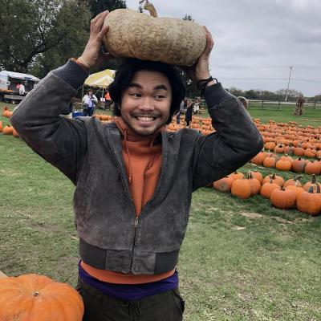

# About

Hi there! I’m an Informatics Analyst at [Emory University](https://www.emory.edu/home/index.html), where I collaborate with researchers to drive data-driven insights that support groundbreaking research and healthcare innovation.

In my role, I apply cutting-edge technologies and biomedical informatics standards to ensure that our informatics systems advance the university’s research objectives. I work closely with researchers to translate their needs into effective technical designs, manage complex data sets, and create accurate reports that contribute to meaningful research outcomes.

In addition to my informatics work, I am also pursuing my Master’s in Computer Science at the [University of Wisconsin - Whitewater](https://www.uww.edu/). My immediate goal is to apply advanced knowledge in Artificial Intelligence and Big Data to enhance my role as an Informatics Analyst.

Post-graduation, I aim to leverage these skills to drive tangible impacts in the field of informatics and pursue a PhD in Computer Science, with a focus on advancing big data analytics and AI, contributing to the continued evolution of the field.

# Personal Projects

## Predicting Cardiac Wellnes: Using a Multi-Layer Perceptron on ECG Data

Utilizing a Multi-Layer Perceptron for analyzing ECG data to detect heart disease offers efficient automation, enabling early identification of abnormalities and arrhythmias. This approach addresses the challenges of manual analysis, providing consistent, objective diagnostics while enhancing the system’s capacity to identify specific types of heart conditions. [[Link to project]](https://github.com/carrliitos/ecg_classification)

## Drone Swarm Coordination Simulation System

In this project, I developed a simulation system to coordinate and control a swarm of drones for various applications. The project includes the creation of algorithms for formation flying, synchronized movements, collaborative tasks, and an obstacle detection and avoidance system within the drone swarm. [[Link to project]](https://github.com/carrliitos/cs-776-drone-swarm)

## NLP - Information Extraction

In my 2020 undergraduate project, I delved into the realm of automated Information Extraction with a specific focus on the medical domain. The objective was to streamline the process of data extraction, automating the creation of an extensive database of CSVs. This initiative aimed to support proprietary research at the University of Wisconsin - Whitewater, contributing to the efficiency and depth of data analysis in the medical field. [[Link to project]](https://github.com/carrliitos/NLPInformationExtraction) [Link to poster] [Link to NLP Methods]

## Smart Parking Assistant Arduino Project

This is a collision avoidance system placed in the garage to help people park their cars safely without hitting their garage walls. For this project, I am using an ultrasonic sensor to calculate the car’s distance from the garage wall and displaying them with green, yellow, and red LEDs to indicate the presence of the car, cautioning the car, letting the car know it is in a danger zone, respectively. [[Link to project]](https://github.com/carrliitos/smartParkingAssistant)

## UW-Whiwater WINS Clone

The Whitewater Information Network for Students (WINS) is a personal online information network that is available for registering classes, checking financial records, viewing your Academic Advising Report (AAR), schedule, tasks, profile, grades, important dates, resources, and help. [[Link to project]](https://github.com/carrliitos/WINS-clone)

## Secure Authentication

My undergraduate secure authentication project that implements RSA and EAS cryptosystems. [[Link to project]](https://github.com/carrliitos/Secure-Authentication-Project)

## Monoalphabetic Decryption

My undergraduate project that performs cryptanalytic Ciphertext-Only Attack (COA) on the provided text document, using letter frequency analysis in Java. [[Link to project]](https://github.com/carrliitos/MonoalphabeticDecryption)

## TerminalChat

A terminal-based chat system that utilizes socket programming. [[Link to project]](https://github.com/carrliitos/TerminalChat)

© Benzon Carlitos Salazar, 2023

[[LinkedIn]](https://www.linkedin.com/in/benzoncarlitossalazar) [[Github]](https://github.com/carrliitos)